# GNET - 4E & diff judgements - basic analysis

# GNET - 4 elements with difference ratings from participants

This is the analysis of the second run of GNET4E. Everything is the same, except that in the study phase participants looked at a familiar first then a novel and rated the subjective difference of the images.

As in the original task, stimuli were algorithmically generated, allowing precise comparison between stimuli. The difference between the stimulus presented and other stimuli (several comparisons are used) is a proxy for novelty.

During familiarization, participants learned a set of 5 stimuli During the study phase, they rated the difference of these stimuli to novels. During the test phase, the performed a recognition memory test for the novels intermixed with distractors. - Novels and distractors were balanced.

In the original GNET, recognition performance tended to increase monotonically with difference to familiars In the GNET4E participants showed their highest categorization performance for stimuli at intermediate levels of difference.

## Exclusions

We excluded 5 participants due to a high number of missed responses in the study phase (≥ 20).

We excluded 8 participants due to a high number of missed responses in the recognition test (> 20).

We excluded 0 participants due to inattention to task details, indicated by a mean difference judgment > 5 for prototype– prototype comparisons.

This left 46 participants in the analysis.

The identifiers are:

501_179, 503_180, 504_190, 505_189, 506_181, 507_187, 508_192, 510_191, 511_193, 514_198, 515_199, 516_200, 517_202, 518_204, 519_203, 520_205, 522_207, 523_208, 524_210, 526_212, 527_213, 528_214, 529_215, 530_240, 531_253, 532_259, 533_262, 534_308, 535_323, 536_324, 539_342, 540_343, 543_367, 544_371, 547_385, 551_407, 554_423, 557_435, 559_449, 560_451, 561_453, 562_456, 564_458, 565_459, 566_462, 567_465

## Demography

The sample had a mean (± SD) age of 21.6086957 ± 3.1445068.

The sample contained 37 women.

# Analysis

## Study phase

Participants make a judgement of the difference between a prototype and a novel picture.

```
## Linear mixed model fit by REML. t-tests use Satterthwaite's method [
## lmerModLmerTest]
## Formula: similarity_rating ~ difference_level + (1 + difference_level |
##     workerId) + (1 | stim)
##    Data: stlmm
##
## REML criterion at convergence: 10510.7
##
## Scaled residuals:
##     Min      1Q  Median      3Q     Max
## -4.0772 -0.6222 -0.0580  0.6053  4.2047
##
## Random effects:
##  Groups   Name             Variance Std.Dev. Corr
##  workerId (Intercept)      0.65162  0.8072
##           difference_level 0.01918  0.1385   -0.34
##  stim     (Intercept)      0.01104  0.1051
##  Residual                  2.92683  1.7108
## Number of obs: 2646, groups:  workerId, 46; stim, 5
##
## Fixed effects:
##                  Estimate Std. Error       df t value Pr(>|t|)
## (Intercept)       2.51958    0.14085 40.88594   17.89   <2e-16 ***
## difference_level  1.19855    0.02817 45.28697   42.55   <2e-16 ***
## ---
## Signif. codes:  0 '***' 0.001 '**' 0.01 '*' 0.05 '.' 0.1 ' ' 1
##
## Correlation of Fixed Effects:
##             (Intr)
## diffrnc_lvl -0.445
## optimizer (nloptwrap) convergence code: 0 (OK)
## Model failed to converge with max|grad| = 0.00218469 (tol = 0.002, component 1)
##   See ?lme4::convergence and ?lme4::troubleshooting.
```

A linear mixed-effects model examined whether participants’ similarity ratings tracked the experimentally manipulated difference levels. Similarity ratings increased significantly as objective difference level increased, β = 1.2, SE = 0.03, *t*(45.29) = 42.55, *p* < .001.

The positive regression coefficient indicates that participants perceived stimuli as increasingly different as their objective difference from the familiar images increased. On average, each one-level increase in objective difference was associated with an increase of approximately 1.2 points on the 9-point similarity rating scale.

### Study phase - Fig

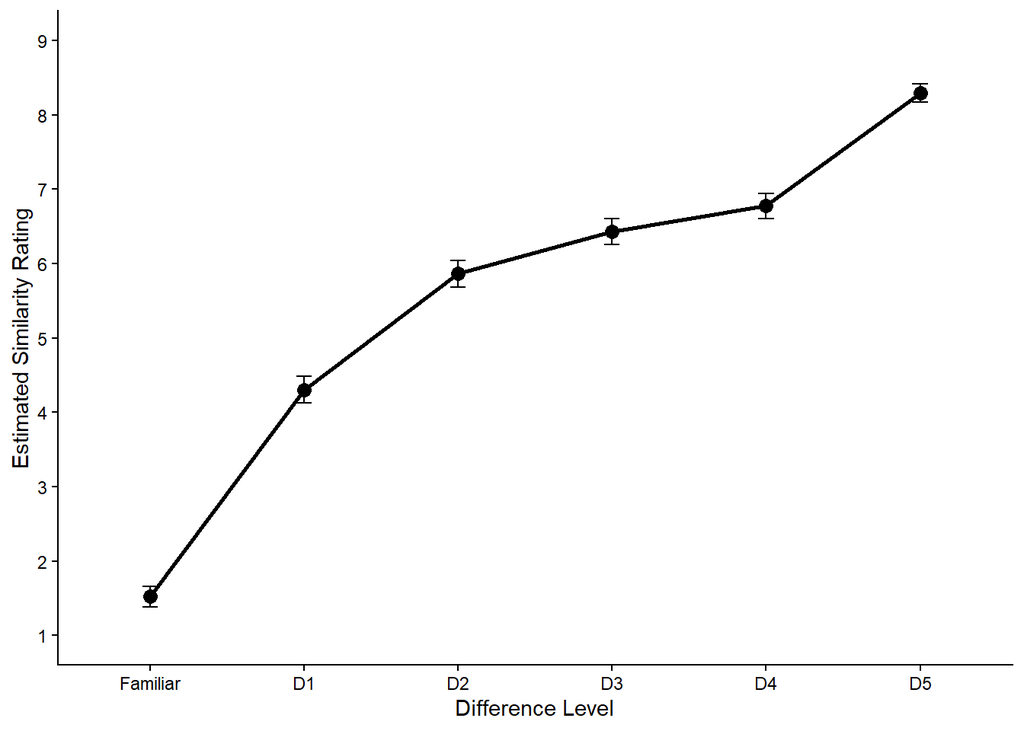

## Test phase

Test phase was the same as before: participants see the novel pictures from the study phase with distractors from the same categories. They signal if they think the picture is an old one from the study phase, or a novel distractor.

Use sum-to-zero contrasts so that coefficients are interpreted as deviations from the grand mean rather than comparisons with the reference level (D1). This is useful when no stimulus type serves as a theoretically meaningful baseline condition.

```
## Generalized linear mixed model fit by maximum likelihood (Laplace
##   Approximation) [glmerMod]
##  Family: binomial  ( logit )
## Formula: rt_resp ~ stimtype * test_quality + (1 | workerId) + (1 | stim)
##    Data: tdlmm
##
##       AIC       BIC    logLik -2*log(L)  df.resid
##    5303.4    5379.8   -2639.7    5279.4      4290
##
## Scaled residuals:
##     Min      1Q  Median      3Q     Max
## -5.9269 -0.8528  0.4119  0.7724  2.5660
##
## Random effects:
##  Groups   Name        Variance Std.Dev.
##  stim     (Intercept) 0.2703   0.5199
##  workerId (Intercept) 0.5387   0.7340
## Number of obs: 4302, groups:  stim, 100; workerId, 46
##
## Fixed effects:
##                         Estimate Std. Error z value Pr(>|z|)
## (Intercept)              0.38801    0.12522   3.099  0.00194 **
## stimtype1               -0.67408    0.12389  -5.441  5.3e-08 ***
## stimtype2               -0.25384    0.12320  -2.060  0.03935 *
## stimtype3                0.12690    0.12436   1.020  0.30751
## stimtype4               -0.12709    0.12362  -1.028  0.30390
## test_quality1           -0.04416    0.06222  -0.710  0.47787
## stimtype1:test_quality1 -0.10147    0.12375  -0.820  0.41223
## stimtype2:test_quality1 -0.03844    0.12318  -0.312  0.75498
## stimtype3:test_quality1 -0.25611    0.12439  -2.059  0.03950 *
## stimtype4:test_quality1  0.24319    0.12362   1.967  0.04915 *
## ---
## Signif. codes:  0 '***' 0.001 '**' 0.01 '*' 0.05 '.' 0.1 ' ' 1
##
## Correlation of Fixed Effects:
##             (Intr) stmty1 stmty2 stmty3 stmty4 tst_q1 st1:_1 st2:_1 st3:_1
## stimtype1   -0.006
## stimtype2   -0.007 -0.242
## stimtype3    0.000 -0.248 -0.246
## stimtype4   -0.005 -0.244 -0.243 -0.247
## test_qulty1  0.001  0.003 -0.002 -0.010  0.000
## stmtyp1:t_1  0.001  0.008 -0.001  0.003 -0.002 -0.007
## stmtyp2:t_1 -0.001 -0.001  0.000  0.006  0.000 -0.013 -0.243
## stmtyp3:t_1 -0.006  0.004  0.006 -0.012  0.005 -0.001 -0.247 -0.245
## stmtyp4:t_1  0.001 -0.003  0.000  0.005  0.003 -0.009 -0.245 -0.243 -0.247
```

```
## $emmeans
## stimtype = D1:
##  test_quality  emmean    SE  df asymp.LCL asymp.UCL
##  fam          -0.4317 0.224 Inf   -0.8710    0.0076
##  new          -0.1404 0.223 Inf   -0.5769    0.2960
##
## stimtype = D2:
##  test_quality  emmean    SE  df asymp.LCL asymp.UCL
##  fam           0.0516 0.222 Inf   -0.3841    0.4872
##  new           0.2168 0.223 Inf   -0.2195    0.6530
##
## stimtype = D3:
##  test_quality  emmean    SE  df asymp.LCL asymp.UCL
##  fam           0.2146 0.223 Inf   -0.2226    0.6519
##  new           0.8152 0.226 Inf    0.3717    1.2586
##
## stimtype = D4:
##  test_quality  emmean    SE  df asymp.LCL asymp.UCL
##  fam           0.4600 0.223 Inf    0.0219    0.8980
##  new           0.0619 0.223 Inf   -0.3751    0.4989
##
## stimtype = D5:
##  test_quality  emmean    SE  df asymp.LCL asymp.UCL
##  fam           1.4248 0.232 Inf    0.9698    1.8798
##  new           1.2075 0.228 Inf    0.7600    1.6549
##
## Results are given on the logit (not the response) scale.
## Confidence level used: 0.95
##
## $contrasts
## stimtype = D1:
##  contrast  estimate    SE  df z.ratio p.value
##  fam - new   -0.291 0.276 Inf  -1.055  0.2916
##
## stimtype = D2:
##  contrast  estimate    SE  df z.ratio p.value
##  fam - new   -0.165 0.274 Inf  -0.602  0.5473
##
## stimtype = D3:
##  contrast  estimate    SE  df z.ratio p.value
##  fam - new   -0.601 0.278 Inf  -2.160  0.0308
##
## stimtype = D4:
##  contrast  estimate    SE  df z.ratio p.value
##  fam - new    0.398 0.276 Inf   1.443  0.1489
##
## stimtype = D5:
##  contrast  estimate    SE  df z.ratio p.value
##  fam - new    0.217 0.287 Inf   0.758  0.4482
##
## Results are given on the log odds ratio (not the response) scale.
```

### Test phase - Figure

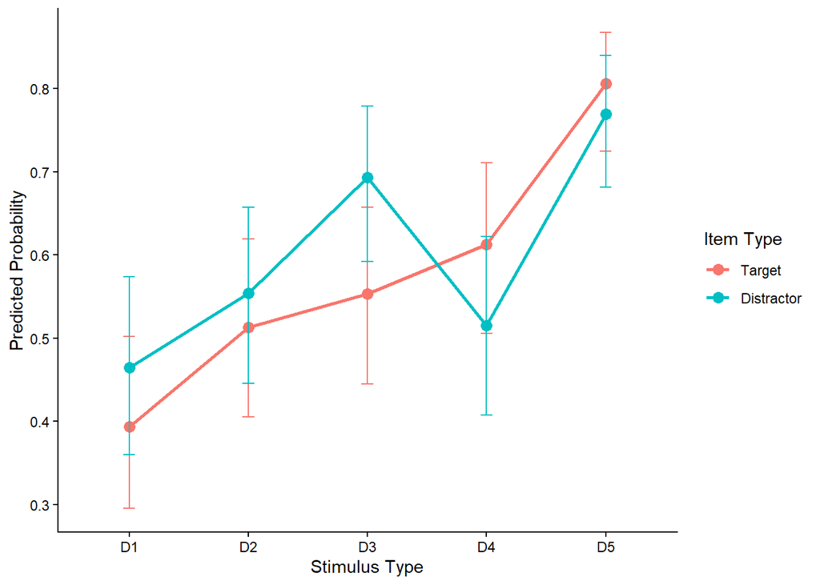